# 06.1_Data_Preprocessing

Major Tasks in data preprocessing:

- Data cleaning
  - **Handling missing values (on HYPOTHYROID dataset)** ✅
  - Smooth noisy data
  - Identify or remove outliers
  - Resolve inconsistencies
  - Encoding categorical features
- Data integration
- Data reduction
  - Dimensionality reduction
  - Numerosity reduction
    - Parametric methods
    - Non parametric methods
      - Sampling
        - Simple random sampling with replacement
        - Simple random sampling without replacement
- Data transformation and data discretization
  - Normalization
  - Concept Hierarchy Generation
  - **Discretization with pandas (on IRIS dataset)** ✅
    - Equal width binning ✅
    - Equal frequency binning ✅

```python
import os
import pandas as pd
import seaborn as sns
import matplotlib.pylab as plt
```

# Data cleaning: handling missing value

Main strategies:

- **ignoring the tuple**
  - ⚠️ risk of shrinking the dataset too much. Problematic, for the downstream ML algorithm
- **filling missing value manually**
  - ⚠️ typically infeasible/tedious
- **imputing missing value (filling automatically)**
  - ⚠️ arbitrary

### The hypothyroid dataset

Thyroid disease records supplied by the Garavan Institute and J. Ross Quinlan, New South Wales Institute, Syndney, Australia.

Missing values are reported with symbol "?", in the original dataset

| column | values |
| --- | --- |
| age | continuous (int) |
| sex | M, F |
| on thyroxine | f, t |
| query on thyroxine | f, t |
| on antithyroid medication | f, t |
| sick | f, t |
| pregnant | f, t |
| thyroid surgery | f, t |
| I131 treatment | f, t |
| query hypothyroid | f, t |
| query hyperthyroid | f, t |
| lithium | f, t |
| goitre | f, t |
| tumor | f, t |
| hypopituitary | f, t |
| psych | f, t |
| TSH measured | f, t |
| TSH | continuous |
| T3 measured | f, t |
| T3 | continuous |
| TT4 measured | f, t |
| TT4 | continuous |
| T4U measured | f, t |
| T4U | continuous |
| FTI measured | f, t |
| FTI | continuous |
| TBG measured | f, t |
| TBG | continuous |
| referral source | WEST, STMW, SVHC, SVI, SVHD, other |
| Class | hypothyroid, primary hypothyroid, compensated hypothyroid, secondary hypothyroid, negative |

Load the hypothyroid dataset

```python
df = pd.read_csv('dataset/hypothyroid.csv', na_values = "?")
df
```

|  | age | sex | on thyroxine | query on thyroxine | on antithyroid medication | sick | pregnant | thyroid surgery | I131 treatment | query hypothyroid | ... | TT4 measured | TT4 | T4U measured | T4U | FTI measured | FTI | TBG measured | TBG | referral source | Class |
| --- | --- | --- | --- | --- | --- | --- | --- | --- | --- | --- | --- | --- | --- | --- | --- | --- | --- | --- | --- | --- | --- |
| 0 | 41.0 | F | f | f | f | f | f | f | f | f | ... | t | 125.0 | t | 1.14 | t | 109.0 | f | NaN | SVHC | negative |
| 1 | 23.0 | F | f | f | f | f | f | f | f | f | ... | t | 102.0 | f | NaN | f | NaN | f | NaN | other | negative |
| 2 | 46.0 | M | f | f | f | f | f | f | f | f | ... | t | 109.0 | t | 0.91 | t | 120.0 | f | NaN | other | negative |
| 3 | 70.0 | F | t | f | f | f | f | f | f | f | ... | t | 175.0 | f | NaN | f | NaN | f | NaN | other | negative |
| 4 | 70.0 | F | f | f | f | f | f | f | f | f | ... | t | 61.0 | t | 0.87 | t | 70.0 | f | NaN | SVI | negative |
| ... | ... | ... | ... | ... | ... | ... | ... | ... | ... | ... | ... | ... | ... | ... | ... | ... | ... | ... | ... | ... | ... |
| 3767 | 30.0 | F | f | f | f | f | f | f | f | f | ... | f | NaN | f | NaN | f | NaN | f | NaN | other | negative |
| 3768 | 68.0 | F | f | f | f | f | f | f | f | f | ... | t | 124.0 | t | 1.08 | t | 114.0 | f | NaN | SVI | negative |
| 3769 | 74.0 | F | f | f | f | f | f | f | f | f | ... | t | 112.0 | t | 1.07 | t | 105.0 | f | NaN | other | negative |
| 3770 | 72.0 | M | f | f | f | f | f | f | f | f | ... | t | 82.0 | t | 0.94 | t | 87.0 | f | NaN | SVI | negative |
| 3771 | 64.0 | F | f | f | f | f | f | f | f | f | ... | t | 99.0 | t | 1.07 | t | 92.0 | f | NaN | other | negative |

3772 rows × 30 columns

```python
df.head().T
```

|  | 0 | 1 | 2 | 3 | 4 |
| --- | --- | --- | --- | --- | --- |
| age | 41.0 | 23.0 | 46.0 | 70.0 | 70.0 |
| sex | F | F | M | F | F |
| on thyroxine | f | f | f | t | f |
| query on thyroxine | f | f | f | f | f |
| on antithyroid medication | f | f | f | f | f |
| sick | f | f | f | f | f |
| pregnant | f | f | f | f | f |
| thyroid surgery | f | f | f | f | f |
| I131 treatment | f | f | f | f | f |
| query hypothyroid | f | f | f | f | f |
| query hyperthyroid | f | f | f | f | f |
| lithium | f | f | f | f | f |
| goitre | f | f | f | f | f |
| tumor | f | f | f | f | f |
| hypopituitary | f | f | f | f | f |
| psych | f | f | f | f | f |
| TSH measured | t | t | t | t | t |
| TSH | 1.3 | 4.1 | 0.98 | 0.16 | 0.72 |
| T3 measured | t | t | f | t | t |
| T3 | 2.5 | 2.0 | NaN | 1.9 | 1.2 |
| TT4 measured | t | t | t | t | t |
| TT4 | 125.0 | 102.0 | 109.0 | 175.0 | 61.0 |
| T4U measured | t | f | t | f | t |
| T4U | 1.14 | NaN | 0.91 | NaN | 0.87 |
| FTI measured | t | f | t | f | t |
| FTI | 109.0 | NaN | 120.0 | NaN | 70.0 |
| TBG measured | f | f | f | f | f |
| TBG | NaN | NaN | NaN | NaN | NaN |
| referral source | SVHC | other | other | other | SVI |
| Class | negative | negative | negative | negative | negative |

```python
df.describe().T
```

|  | count | mean | std | min | 25% | 50% | 75% | max |
| --- | --- | --- | --- | --- | --- | --- | --- | --- |
| age | 3771.0 | 51.735879 | 20.084958 | 1.000 | 36.00 | 54.00 | 67.00 | 455.00 |
| TSH | 3403.0 | 5.086766 | 24.521470 | 0.005 | 0.50 | 1.40 | 2.70 | 530.00 |
| T3 | 3003.0 | 2.013500 | 0.827434 | 0.050 | 1.60 | 2.00 | 2.40 | 10.60 |
| TT4 | 3541.0 | 108.319345 | 35.604248 | 2.000 | 88.00 | 103.00 | 124.00 | 430.00 |
| T4U | 3385.0 | 0.995000 | 0.195457 | 0.250 | 0.88 | 0.98 | 1.08 | 2.32 |
| FTI | 3387.0 | 110.469649 | 33.089698 | 2.000 | 93.00 | 107.00 | 124.00 | 395.00 |
| TBG | 0.0 | NaN | NaN | NaN | NaN | NaN | NaN | NaN |

```python
df.describe(include = 'object').T
```

|  | count | unique | top | freq |
| --- | --- | --- | --- | --- |
| sex | 3622 | 2 | F | 2480 |
| on thyroxine | 3772 | 2 | f | 3308 |
| query on thyroxine | 3772 | 2 | f | 3722 |
| on antithyroid medication | 3772 | 2 | f | 3729 |
| sick | 3772 | 2 | f | 3625 |
| pregnant | 3772 | 2 | f | 3719 |
| thyroid surgery | 3772 | 2 | f | 3719 |
| I131 treatment | 3772 | 2 | f | 3713 |
| query hypothyroid | 3772 | 2 | f | 3538 |
| query hyperthyroid | 3772 | 2 | f | 3535 |
| lithium | 3772 | 2 | f | 3754 |
| goitre | 3772 | 2 | f | 3738 |
| tumor | 3772 | 2 | f | 3676 |
| hypopituitary | 3772 | 2 | f | 3771 |
| psych | 3772 | 2 | f | 3588 |
| TSH measured | 3772 | 2 | t | 3403 |
| T3 measured | 3772 | 2 | t | 3003 |
| TT4 measured | 3772 | 2 | t | 3541 |
| T4U measured | 3772 | 2 | t | 3385 |
| FTI measured | 3772 | 2 | t | 3387 |
| TBG measured | 3772 | 1 | f | 3772 |
| referral source | 3772 | 5 | other | 2201 |
| Class | 3772 | 4 | negative | 3481 |

```python
df.isna().sum(axis=0)
```

```
age                             1
sex                           150
on thyroxine                    0
query on thyroxine              0
on antithyroid medication       0
sick                            0
pregnant                        0
thyroid surgery                 0
I131 treatment                  0
query hypothyroid               0
query hyperthyroid              0
lithium                         0
goitre                          0
tumor                           0
hypopituitary                   0
psych                           0
TSH measured                    0
TSH                           369
T3 measured                     0
T3                            769
TT4 measured                    0
TT4                           231
T4U measured                    0
T4U                           387
FTI measured                    0
FTI                           385
TBG measured                    0
TBG                          3772
referral source                 0
Class                           0
dtype: int64
```

Attribute removal:

- "*TBG*" column has only missing values - we can drop it
- "*TBG measured*" has only one unique value - we can drop it

```python
df = df.drop(['TBG', 'TBG measured'], axis = 1)
df
```

|  | age | sex | on thyroxine | query on thyroxine | on antithyroid medication | sick | pregnant | thyroid surgery | I131 treatment | query hypothyroid | ... | T3 measured | T3 | TT4 measured | TT4 | T4U measured | T4U | FTI measured | FTI | referral source | Class |
| --- | --- | --- | --- | --- | --- | --- | --- | --- | --- | --- | --- | --- | --- | --- | --- | --- | --- | --- | --- | --- | --- |
| 0 | 41.0 | F | f | f | f | f | f | f | f | f | ... | t | 2.5 | t | 125.0 | t | 1.14 | t | 109.0 | SVHC | negative |
| 1 | 23.0 | F | f | f | f | f | f | f | f | f | ... | t | 2.0 | t | 102.0 | f | NaN | f | NaN | other | negative |
| 2 | 46.0 | M | f | f | f | f | f | f | f | f | ... | f | NaN | t | 109.0 | t | 0.91 | t | 120.0 | other | negative |
| 3 | 70.0 | F | t | f | f | f | f | f | f | f | ... | t | 1.9 | t | 175.0 | f | NaN | f | NaN | other | negative |
| 4 | 70.0 | F | f | f | f | f | f | f | f | f | ... | t | 1.2 | t | 61.0 | t | 0.87 | t | 70.0 | SVI | negative |
| ... | ... | ... | ... | ... | ... | ... | ... | ... | ... | ... | ... | ... | ... | ... | ... | ... | ... | ... | ... | ... | ... |
| 3767 | 30.0 | F | f | f | f | f | f | f | f | f | ... | f | NaN | f | NaN | f | NaN | f | NaN | other | negative |
| 3768 | 68.0 | F | f | f | f | f | f | f | f | f | ... | t | 2.1 | t | 124.0 | t | 1.08 | t | 114.0 | SVI | negative |
| 3769 | 74.0 | F | f | f | f | f | f | f | f | f | ... | t | 1.8 | t | 112.0 | t | 1.07 | t | 105.0 | other | negative |
| 3770 | 72.0 | M | f | f | f | f | f | f | f | f | ... | t | 2.0 | t | 82.0 | t | 0.94 | t | 87.0 | SVI | negative |
| 3771 | 64.0 | F | f | f | f | f | f | f | f | f | ... | t | 2.2 | t | 99.0 | t | 1.07 | t | 92.0 | other | negative |

3772 rows × 28 columns

Handling missing values: **ignoring the tuple**

```python
df_notna = df.dropna(how = 'any')
print(df_notna.isna().sum())
df_notna
```

```
age                          0
sex                          0
on thyroxine                 0
query on thyroxine           0
on antithyroid medication    0
sick                         0
pregnant                     0
thyroid surgery              0
I131 treatment               0
query hypothyroid            0
query hyperthyroid           0
lithium                      0
goitre                       0
tumor                        0
hypopituitary                0
psych                        0
TSH measured                 0
TSH                          0
T3 measured                  0
T3                           0
TT4 measured                 0
TT4                          0
T4U measured                 0
T4U                          0
FTI measured                 0
FTI                          0
referral source              0
Class                        0
dtype: int64
```

|  | age | sex | on thyroxine | query on thyroxine | on antithyroid medication | sick | pregnant | thyroid surgery | I131 treatment | query hypothyroid | ... | T3 measured | T3 | TT4 measured | TT4 | T4U measured | T4U | FTI measured | FTI | referral source | Class |
| --- | --- | --- | --- | --- | --- | --- | --- | --- | --- | --- | --- | --- | --- | --- | --- | --- | --- | --- | --- | --- | --- |
| 0 | 41.0 | F | f | f | f | f | f | f | f | f | ... | t | 2.5 | t | 125.0 | t | 1.14 | t | 109.0 | SVHC | negative |
| 4 | 70.0 | F | f | f | f | f | f | f | f | f | ... | t | 1.2 | t | 61.0 | t | 0.87 | t | 70.0 | SVI | negative |
| 7 | 80.0 | F | f | f | f | f | f | f | f | f | ... | t | 0.6 | t | 80.0 | t | 0.70 | t | 115.0 | SVI | negative |
| 8 | 66.0 | F | f | f | f | f | f | f | f | f | ... | t | 2.2 | t | 123.0 | t | 0.93 | t | 132.0 | SVI | negative |
| 9 | 68.0 | M | f | f | f | f | f | f | f | f | ... | t | 1.6 | t | 83.0 | t | 0.89 | t | 93.0 | SVI | negative |
| ... | ... | ... | ... | ... | ... | ... | ... | ... | ... | ... | ... | ... | ... | ... | ... | ... | ... | ... | ... | ... | ... |
| 3766 | 19.0 | F | f | f | f | f | f | f | f | f | ... | t | 2.7 | t | 108.0 | t | 1.11 | t | 97.0 | other | compensated_hypothyroid |
| 3768 | 68.0 | F | f | f | f | f | f | f | f | f | ... | t | 2.1 | t | 124.0 | t | 1.08 | t | 114.0 | SVI | negative |
| 3769 | 74.0 | F | f | f | f | f | f | f | f | f | ... | t | 1.8 | t | 112.0 | t | 1.07 | t | 105.0 | other | negative |
| 3770 | 72.0 | M | f | f | f | f | f | f | f | f | ... | t | 2.0 | t | 82.0 | t | 0.94 | t | 87.0 | SVI | negative |
| 3771 | 64.0 | F | f | f | f | f | f | f | f | f | ... | t | 2.2 | t | 99.0 | t | 1.07 | t | 92.0 | other | negative |

2643 rows × 28 columns

Notice that with this strategy we lost around 30% of the tuples

```python
len(df_notna) / len(df)
```

```
0.7006892895015907
```

Variation of classes distribution.

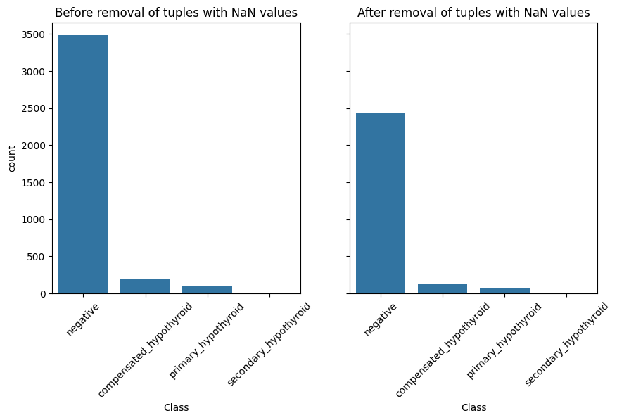

```python
fig,axes = plt.subplots(1, 2, figsize = (10, 5), sharey = True)

sns.countplot(x = 'Class',
              data = df,
              ax = axes[0],
              order = df_notna['Class'].value_counts().index)
axes[0].tick_params(axis = 'x', labelrotation = 45)
axes[0].set_title('Before removal of tuples with NaN values')

sns.countplot(x = 'Class',
              data = df_notna,
              ax = axes[1],
              order = df_notna['Class'].value_counts().index)
axes[1].tick_params(axis = 'x', labelrotation = 45)
axes[1].set_title('After removal of tuples with NaN values')

plt.show()
```

Variation of attribute statistics, grouped by class.

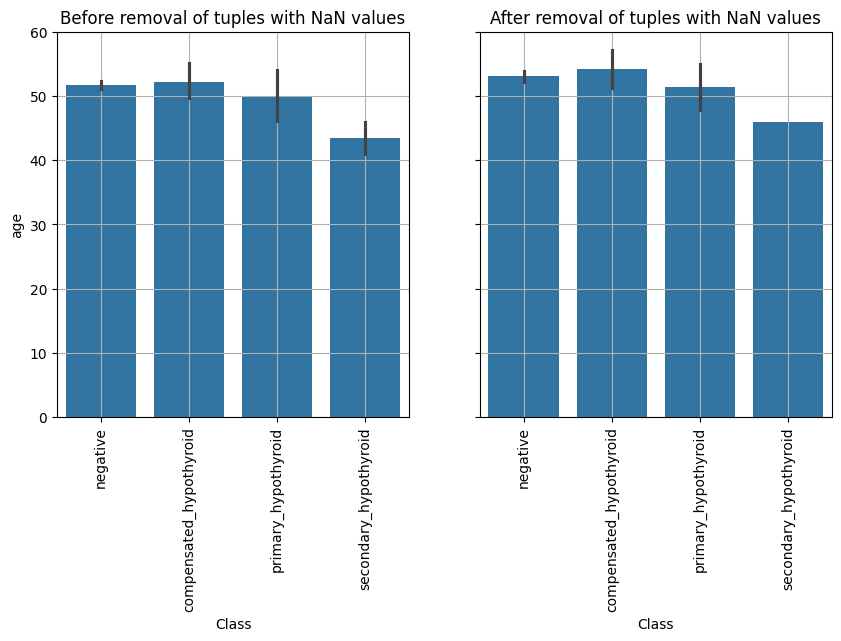

```python
fig, axes = plt.subplots(1, 2, figsize = (10, 5), sharey = True)

sns.barplot(y = 'age',
            x = 'Class',
            data = df,
            ax = axes[0],
            order = df_notna['Class'].value_counts().index)
axes[0].tick_params(axis = 'x', labelrotation = 90)
axes[0].grid()
axes[0].set_title('Before removal of tuples with NaN values')

sns.barplot(y = 'age',
            x = 'Class',
            data = df_notna,
            ax = axes[1],
            order = df_notna['Class'].value_counts().index)
axes[1].tick_params(axis = 'x', labelrotation = 90)
axes[1].set_title('After removal of tuples with NaN values')
axes[1].grid()

plt.show()
```

Handling missing values: **imputing missing value (filling automatically)**

Create a novel ad-hoc category

```python
df.sex.fillna('NS').value_counts()
```

```
sex
F     2480
M     1142
NS     150
Name: count, dtype: int64
```

```python
df.sex.value_counts()
```

```
sex
F    2480
M    1142
Name: count, dtype: int64
```

Categorical attribute: assign the most frequent value

```python
df.sex.mode()[0]
```

```
'F'
```

```python
df.sex.fillna(df.sex.mode()[0]).value_counts()
```

```
sex
F    2630
M    1142
Name: count, dtype: int64
```

```python
df.sex.value_counts()
```

```
sex
F    2480
M    1142
Name: count, dtype: int64
```

Numerical attribute: assign the mean value

```python
df[df.age.isna()]
```

|  | age | sex | on thyroxine | query on thyroxine | on antithyroid medication | sick | pregnant | thyroid surgery | I131 treatment | query hypothyroid | ... | T3 measured | T3 | TT4 measured | TT4 | T4U measured | T4U | FTI measured | FTI | referral source | Class |
| --- | --- | --- | --- | --- | --- | --- | --- | --- | --- | --- | --- | --- | --- | --- | --- | --- | --- | --- | --- | --- | --- |
| 1985 | NaN | F | t | f | f | f | f | f | t | f | ... | t | 1.5 | t | 120.0 | t | 0.82 | t | 146.0 | other | negative |

1 rows × 28 columns

```python
print(df.age.mean())
df['age'].fillna(df.age.mean())[1985]
```

```
51.73587907716786
```

```
np.float64(51.73587907716786)
```

More imputing strategies available in `scikit-learn` (only for numeric attributes). We will extensively cover `scikit-learn` in the next lectures. In the following, a simple example is reported.

```python
import numpy as np
from sklearn.impute import KNNImputer, SimpleImputer
```

```python
X = np.asarray([[1, 2, np.nan], [3, 4, 3], [np.nan, 6, 5], [8, 8, 7], [3, 6, 5], [1, 3, 5], [2, 7, 5]])
print(X)
```

```
[[ 1.  2. nan]
 [ 3.  4.  3.]
 [nan  6.  5.]
 [ 8.  8.  7.]
 [ 3.  6.  5.]
 [ 1.  3.  5.]
 [ 2.  7.  5.]]
```

**Simple imputer**: univariate imputer for completing missing values with simple strategies.

Replace missing values using a descriptive statistic (e.g. mean, median, or most frequent) along each column, or using a constant value.

```python
imputer = SimpleImputer() # by default, it uses the "mean"
imputer.fit_transform(X)
```

```
array([[1., 2., 5.],
       [3., 4., 3.],
       [3., 6., 5.],
       [8., 8., 7.],
       [3., 6., 5.],
       [1., 3., 5.],
       [2., 7., 5.]])
```

**KNN-imputer**: Imputation for completing missing values using k-Nearest Neighbors.

Each sample’s missing values are imputed using the mean value from *n_neighbors* nearest neighbors found in the training set. Two samples are close if the features that neither is missing are close.

```python
imputer = KNNImputer(n_neighbors = 2)
imputer.fit_transform(X)
```

```
array([[1. , 2. , 4. ],
       [3. , 4. , 3. ],
       [2.5, 6. , 5. ],
       [8. , 8. , 7. ],
       [3. , 6. , 5. ],
       [1. , 3. , 5. ],
       [2. , 7. , 5. ]])
```

**Iterative imputer**: Multivariate imputer that estimates each feature as a function of all the others.

*This estimator is still experimental for now: the predictions and the API might change without any deprecation cycle.*

# Data Discretization

Load the IRIS dataset.

```python
df = pd.read_csv(os.path.join('dataset', 'iris.csv'))
df
```

|  | sepallength | sepalwidth | petallength | petalwidth | class |
| --- | --- | --- | --- | --- | --- |
| 0 | 5.1 | 3.5 | 1.4 | 0.2 | 1 |
| 1 | 4.9 | 3.0 | 1.4 | 0.2 | 1 |
| 2 | 4.7 | 3.2 | 1.3 | 0.2 | 1 |
| 3 | 4.6 | 3.1 | 1.5 | 0.2 | 1 |
| 4 | 5.0 | 3.6 | 1.4 | 0.2 | 1 |
| ... | ... | ... | ... | ... | ... |
| 145 | 6.7 | 3.0 | 5.2 | 2.3 | 3 |
| 146 | 6.3 | 2.5 | 5.0 | 1.9 | 3 |
| 147 | 6.5 | 3.0 | 5.2 | 2.0 | 3 |
| 148 | 6.2 | 3.4 | 5.4 | 2.3 | 3 |
| 149 | 5.9 | 3.0 | 5.1 | 1.8 | 3 |

150 rows × 5 columns

## Discretization with pandas

Sometimes we may need to transform a continuous variable to a categorical one. For example, we may want to convert ages to groups of age ranges.

`Pandas` provides two functions for binning values of a continuous variable into discrete intervals. Let *x* be the input array to be binned.

- `pd.cut(x, bins, ...)`: generic function for binning
  - bins:
    - *int*: number of bins (support for **equal-width** binning)
    - *sequence of scalars*: bins edges (support for **non-uniform** width binning)
- `pd.qcut(x, q, ...)`: quantile-based discretization function.
  - q:
    - *int*: number of quantiles (support for **equal-frequency** binning)
    - *list of float*: array of quantiles (support for **custom-frequency** binning)

### Equal-width discretization

```python
df['sepallength_cat'], bins = pd.cut(df.sepallength, 5, retbins = True)
df
```

|  | sepallength | sepalwidth | petallength | petalwidth | class | sepallength_cat |
| --- | --- | --- | --- | --- | --- | --- |
| 0 | 5.1 | 3.5 | 1.4 | 0.2 | 1 | (5.02, 5.74] |
| 1 | 4.9 | 3.0 | 1.4 | 0.2 | 1 | (4.296, 5.02] |
| 2 | 4.7 | 3.2 | 1.3 | 0.2 | 1 | (4.296, 5.02] |
| 3 | 4.6 | 3.1 | 1.5 | 0.2 | 1 | (4.296, 5.02] |
| 4 | 5.0 | 3.6 | 1.4 | 0.2 | 1 | (4.296, 5.02] |
| ... | ... | ... | ... | ... | ... | ... |
| 145 | 6.7 | 3.0 | 5.2 | 2.3 | 3 | (6.46, 7.18] |
| 146 | 6.3 | 2.5 | 5.0 | 1.9 | 3 | (5.74, 6.46] |
| 147 | 6.5 | 3.0 | 5.2 | 2.0 | 3 | (6.46, 7.18] |
| 148 | 6.2 | 3.4 | 5.4 | 2.3 | 3 | (5.74, 6.46] |
| 149 | 5.9 | 3.0 | 5.1 | 1.8 | 3 | (5.74, 6.46] |

150 rows × 6 columns

Plot the novel categorical variable:

```python
df.info()
```

```
<class 'pandas.core.frame.DataFrame'>
RangeIndex: 150 entries, 0 to 149
Data columns (total 6 columns):
 #   Column           Non-Null Count  Dtype
---  ------           --------------  -----
 0   sepallength      150 non-null    float64
 1   sepalwidth       150 non-null    float64
 2   petallength      150 non-null    float64
 3   petalwidth       150 non-null    float64
 4   class            150 non-null    int64
 5   sepallength_cat  150 non-null    category
dtypes: category(1), float64(4), int64(1)
memory usage: 6.4 KB
```

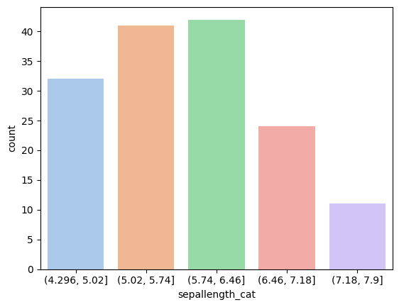

```python
sns.countplot(x = 'sepallength_cat',
              hue = 'sepallength_cat',
              data = df,
              palette = 'pastel',
              legend = False)
plt.show()
```

Plot the novel categorical variable, by class:

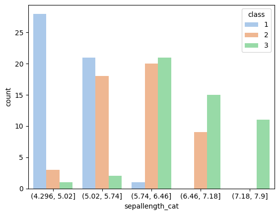

```python
sns.countplot(x = 'sepallength_cat',
              hue = 'class',
              data = df,
              palette = 'pastel')
plt.show()
```

How do the bins look like?

```python
print(bins)
```

```
[4.2964 5.02   5.74   6.46   7.18   7.9   ]
```

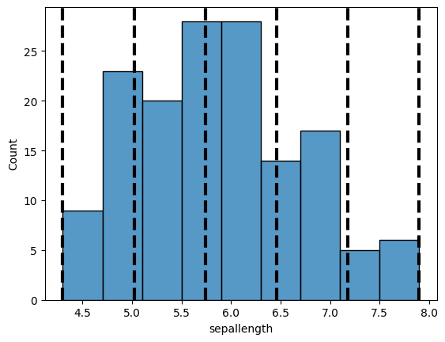

```python
sns.histplot(x = 'sepallength', data = df)
for edge in bins:
    plt.axvline(edge,
                color = 'k',
                linestyle = '--',
                linewidth = 3)
```

### Equal-frequency discretization

```python
# suppose that we want to end up with 4 categories
nbins = 4

df['petallength_cat'], bins = pd.cut(df.petallength, nbins, retbins = True)
df['petallength_qcat'], qbins = pd.qcut(df.petallength, nbins, retbins = True)
df
```

|  | sepallength | sepalwidth | petallength | petalwidth | class | sepallength_cat | petallength_cat | petallength_qcat |
| --- | --- | --- | --- | --- | --- | --- | --- | --- |
| 0 | 5.1 | 3.5 | 1.4 | 0.2 | 1 | (5.02, 5.74] | (0.994, 2.475] | (0.999, 1.6] |
| 1 | 4.9 | 3.0 | 1.4 | 0.2 | 1 | (4.296, 5.02] | (0.994, 2.475] | (0.999, 1.6] |
| 2 | 4.7 | 3.2 | 1.3 | 0.2 | 1 | (4.296, 5.02] | (0.994, 2.475] | (0.999, 1.6] |
| 3 | 4.6 | 3.1 | 1.5 | 0.2 | 1 | (4.296, 5.02] | (0.994, 2.475] | (0.999, 1.6] |
| 4 | 5.0 | 3.6 | 1.4 | 0.2 | 1 | (4.296, 5.02] | (0.994, 2.475] | (0.999, 1.6] |
| ... | ... | ... | ... | ... | ... | ... | ... | ... |
| 145 | 6.7 | 3.0 | 5.2 | 2.3 | 3 | (6.46, 7.18] | (3.95, 5.425] | (5.1, 6.9] |
| 146 | 6.3 | 2.5 | 5.0 | 1.9 | 3 | (5.74, 6.46] | (3.95, 5.425] | (4.35, 5.1] |
| 147 | 6.5 | 3.0 | 5.2 | 2.0 | 3 | (6.46, 7.18] | (3.95, 5.425] | (5.1, 6.9] |
| 148 | 6.2 | 3.4 | 5.4 | 2.3 | 3 | (5.74, 6.46] | (3.95, 5.425] | (5.1, 6.9] |
| 149 | 5.9 | 3.0 | 5.1 | 1.8 | 3 | (5.74, 6.46] | (3.95, 5.425] | (4.35, 5.1] |

150 rows × 8 columns

```python
df.info()
```

```
<class 'pandas.core.frame.DataFrame'>
RangeIndex: 150 entries, 0 to 149
Data columns (total 8 columns):
 #   Column            Non-Null Count  Dtype
---  ------            --------------  -----
 0   sepallength       150 non-null    float64
 1   sepalwidth        150 non-null    float64
 2   petallength       150 non-null    float64
 3   petalwidth        150 non-null    float64
 4   class             150 non-null    int64
 5   sepallength_cat   150 non-null    category
 6   petallength_cat   150 non-null    category
 7   petallength_qcat  150 non-null    category
dtypes: category(3), float64(4), int64(1)
memory usage: 7.3 KB
```

```python
df.describe()
```

|  | sepallength | sepalwidth | petallength | petalwidth | class |
| --- | --- | --- | --- | --- | --- |
| count | 150.000000 | 150.000000 | 150.000000 | 150.000000 | 150.000000 |
| mean | 5.843333 | 3.054000 | 3.758667 | 1.198667 | 2.000000 |
| std | 0.828066 | 0.433594 | 1.764420 | 0.763161 | 0.819232 |
| min | 4.300000 | 2.000000 | 1.000000 | 0.100000 | 1.000000 |
| 25% | 5.100000 | 2.800000 | 1.600000 | 0.300000 | 1.000000 |
| 50% | 5.800000 | 3.000000 | 4.350000 | 1.300000 | 2.000000 |
| 75% | 6.400000 | 3.300000 | 5.100000 | 1.800000 | 3.000000 |
| max | 7.900000 | 4.400000 | 6.900000 | 2.500000 | 3.000000 |

```python
df.describe(include = 'category')
```

|  | sepallength_cat | petallength_cat | petallength_qcat |
| --- | --- | --- | --- |
| count | 150 | 150 | 150 |
| unique | 5 | 4 | 4 |
| top | (5.74, 6.46] | (3.95, 5.425] | (0.999, 1.6] |
| freq | 42 | 61 | 44 |

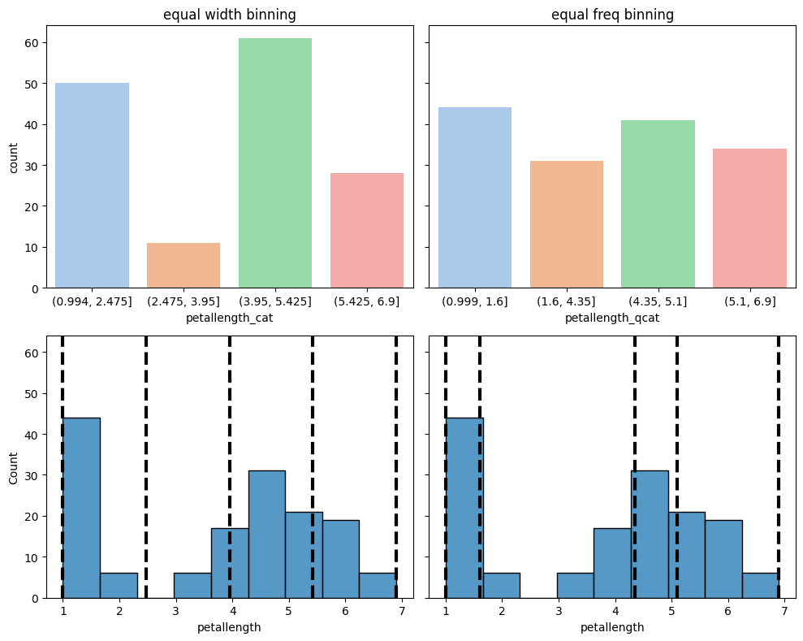

```python
fig, axes = plt.subplots(2, 2, figsize = (10, 8), sharey = True)

# axes[0][0]: top-left
sns.countplot(x = 'petallength_cat',
              hue = 'petallength_cat',
              data = df,
              palette = 'pastel',
              ax = axes[0][0],
              legend = False)
axes[0][0].set_title('equal width binning')

# axes[0][1]: top-right
sns.countplot(x = 'petallength_qcat',
              hue = 'petallength_qcat',
              data = df,
              palette = 'pastel',
              ax = axes[0][1],
              legend = False)
axes[0][1].set_title('equal freq binning')

# axes[1][0]: bottom-left
sns.histplot(x = 'petallength',
             data = df,
             ax = axes[1][0])
for edge in bins:
    axes[1][0].axvline(edge,
                       color = 'k',
                       linestyle = '--',
                       linewidth = 3)

# axes[1][1]: bottom-left
sns.histplot(x = 'petallength',
             data = df,
             ax = axes[1][1])
for edge in qbins:
    axes[1][1].axvline(edge,
                       color = 'k',
                       linestyle = '--',
                       linewidth = 3)

# Improve subplot size/spacing
fig.tight_layout()
```

**binarization** can be simply obtained using `cut()` and `qcut()` by setting nbins = 2

```python
df['sepalwidth_bin'], bins = pd.cut(df.sepalwidth, 2, retbins = True)
df.sepalwidth_bin.value_counts()
```

```
sepalwidth_bin
(1.998, 3.2]    108
(3.2, 4.4]       42
Name: count, dtype: int64
```

```python
df['sepalwidth_qbin'], bins = pd.qcut(df.sepalwidth, 2, retbins = True)
df.sepalwidth_qbin.value_counts()
```

```
sepalwidth_qbin
(1.999, 3.0]    83
(3.0, 4.4]      67
Name: count, dtype: int64
```

Alternatively, we can use a simple threshold function.

```python
df['sepalwidth_bin_custom'] = (df["sepalwidth"] <= 3.0).astype(int)
df.sepalwidth_bin_custom.value_counts()
```

```
sepalwidth_bin_custom
1    83
0    67
Name: count, dtype: int64
```

```python
df['sepalwidth_bin_custom'] =  (df["sepalwidth"] <= 2.9).astype(int)
df.sepalwidth_bin_custom.value_counts()
```

```
sepalwidth_bin_custom
0    93
1    57
Name: count, dtype: int64
```

`qcut()` does its best to get equifrequent bins, but of course it depends on the data and the numerical precision.

### From categorical to numerical

Note that ordinal / interval scaled variable should be treated as such for downstream elaboration (e.g., similarity/distance evaluation).

```python
df
```

|  | sepallength | sepalwidth | petallength | petalwidth | class | sepallength_cat | petallength_cat | petallength_qcat | sepalwidth_bin | sepalwidth_qbin | sepalwidth_bin_custom |
| --- | --- | --- | --- | --- | --- | --- | --- | --- | --- | --- | --- |
| 0 | 5.1 | 3.5 | 1.4 | 0.2 | 1 | (5.02, 5.74] | (0.994, 2.475] | (0.999, 1.6] | (3.2, 4.4] | (3.0, 4.4] | 0 |
| 1 | 4.9 | 3.0 | 1.4 | 0.2 | 1 | (4.296, 5.02] | (0.994, 2.475] | (0.999, 1.6] | (1.998, 3.2] | (1.999, 3.0] | 0 |
| 2 | 4.7 | 3.2 | 1.3 | 0.2 | 1 | (4.296, 5.02] | (0.994, 2.475] | (0.999, 1.6] | (1.998, 3.2] | (3.0, 4.4] | 0 |
| 3 | 4.6 | 3.1 | 1.5 | 0.2 | 1 | (4.296, 5.02] | (0.994, 2.475] | (0.999, 1.6] | (1.998, 3.2] | (3.0, 4.4] | 0 |
| 4 | 5.0 | 3.6 | 1.4 | 0.2 | 1 | (4.296, 5.02] | (0.994, 2.475] | (0.999, 1.6] | (3.2, 4.4] | (3.0, 4.4] | 0 |
| ... | ... | ... | ... | ... | ... | ... | ... | ... | ... | ... | ... |
| 145 | 6.7 | 3.0 | 5.2 | 2.3 | 3 | (6.46, 7.18] | (3.95, 5.425] | (5.1, 6.9] | (1.998, 3.2] | (1.999, 3.0] | 0 |
| 146 | 6.3 | 2.5 | 5.0 | 1.9 | 3 | (5.74, 6.46] | (3.95, 5.425] | (4.35, 5.1] | (1.998, 3.2] | (1.999, 3.0] | 1 |
| 147 | 6.5 | 3.0 | 5.2 | 2.0 | 3 | (6.46, 7.18] | (3.95, 5.425] | (5.1, 6.9] | (1.998, 3.2] | (1.999, 3.0] | 0 |
| 148 | 6.2 | 3.4 | 5.4 | 2.3 | 3 | (5.74, 6.46] | (3.95, 5.425] | (5.1, 6.9] | (3.2, 4.4] | (3.0, 4.4] | 0 |
| 149 | 5.9 | 3.0 | 5.1 | 1.8 | 3 | (5.74, 6.46] | (3.95, 5.425] | (4.35, 5.1] | (1.998, 3.2] | (1.999, 3.0] | 0 |

150 rows × 11 columns

Consider, for example, the breast_cancer dataset:

| column | values |
| --- | --- |
| Class | no-recurrence-events, recurrence-events |
| age | 10-19, 20-29, 30-39, 40-49, 50-59, 60-69, 70-79, 80-89, 90-99 |
| menopause | lt40, ge40, premeno |
| tumor-size | 0-4, 5-9, 10-14, 15-19, 20-24, 25-29, 30-34, 35-39, 40-44, 45-49, 50-54, 55-59 |
| inv-nodes | 0-2, 3-5, 6-8, 9-11, 12-14, 15-17, 18-20, 21-23, 24-26, 27-29, 30-32, 33-35, 36-39 |
| node-caps | yes, no |
| deg-malig | 1, 2, 3 |
| breast | left, right |
| breast-quad | left-up, left-low, right-up, right-low, central |
| irradiat | yes, no |

Suppose that a iris_cat dataset is represented as follows.

```python
categorical_variables = ['sepallength_cat', 'petallength_cat']
```

```python
iris_cat_df = df[categorical_variables].copy() # a new object will be created with a copy of the calling object’s data and indices.
iris_cat_df
```

|  | sepallength_cat | petallength_cat |
| --- | --- | --- |
| 0 | (5.02, 5.74] | (0.994, 2.475] |
| 1 | (4.296, 5.02] | (0.994, 2.475] |
| 2 | (4.296, 5.02] | (0.994, 2.475] |
| 3 | (4.296, 5.02] | (0.994, 2.475] |
| 4 | (4.296, 5.02] | (0.994, 2.475] |
| ... | ... | ... |
| 145 | (6.46, 7.18] | (3.95, 5.425] |
| 146 | (5.74, 6.46] | (3.95, 5.425] |
| 147 | (6.46, 7.18] | (3.95, 5.425] |
| 148 | (5.74, 6.46] | (3.95, 5.425] |
| 149 | (5.74, 6.46] | (3.95, 5.425] |

150 rows × 2 columns

```python
iris_cat_df['sepallength_mean'] = iris_cat_df.sepallength_cat.apply(lambda x: x.mid)
iris_cat_df['petallength_mean'] = iris_cat_df.petallength_cat.apply(lambda x: x.mid)
```

```python
iris_cat_df
```

|  | sepallength_cat | petallength_cat | sepallength_mean | petallength_mean |
| --- | --- | --- | --- | --- |
| 0 | (5.02, 5.74] | (0.994, 2.475] | 5.380 | 1.7345 |
| 1 | (4.296, 5.02] | (0.994, 2.475] | 4.658 | 1.7345 |
| 2 | (4.296, 5.02] | (0.994, 2.475] | 4.658 | 1.7345 |
| 3 | (4.296, 5.02] | (0.994, 2.475] | 4.658 | 1.7345 |
| 4 | (4.296, 5.02] | (0.994, 2.475] | 4.658 | 1.7345 |
| ... | ... | ... | ... | ... |
| 145 | (6.46, 7.18] | (3.95, 5.425] | 6.820 | 4.6875 |
| 146 | (5.74, 6.46] | (3.95, 5.425] | 6.100 | 4.6875 |
| 147 | (6.46, 7.18] | (3.95, 5.425] | 6.820 | 4.6875 |
| 148 | (5.74, 6.46] | (3.95, 5.425] | 6.100 | 4.6875 |
| 149 | (5.74, 6.46] | (3.95, 5.425] | 6.100 | 4.6875 |

150 rows × 4 columns

```python
iris_num = iris_cat_df.iloc[:, -2:]
iris_num
```

|  | sepallength_mean | petallength_mean |
| --- | --- | --- |
| 0 | 5.380 | 1.7345 |
| 1 | 4.658 | 1.7345 |
| 2 | 4.658 | 1.7345 |
| 3 | 4.658 | 1.7345 |
| 4 | 4.658 | 1.7345 |
| ... | ... | ... |
| 145 | 6.820 | 4.6875 |
| 146 | 6.100 | 4.6875 |
| 147 | 6.820 | 4.6875 |
| 148 | 6.100 | 4.6875 |
| 149 | 6.100 | 4.6875 |

150 rows × 2 columns

The *mid* attribute is convenient when we have pandas CategoricalDtype.

In general, we can define custom mappings: e.g., how could we handle the age variable of breast_cancer, in which intervals are represented as strings?

```
dict_categories: {"10-19":15, "20-29":25, "30-39":35, "40-49":45, "50-59":55, "60-69":65, "70-79":75, "80-89":85, "90-99":95}
```